# How to access data from traitdata

RS-eco

2022-01-20

## Getting started

Load the traitdata, dplyr and ggplot2 library

```r
library(traitdata)
library(dplyr, quiet=TRUE)
library(ggplot2)
```

## Data query

To connect to a table within our database, we use the `data()` function.

```r
data(passerines)
```

Now we can use standard R calls to have a look at the table. Here, we check the class and first 6 rows of the table:

```r
class(passerines)
```

```
#> [1] "data.frame"
```

```r
head(passerines)
```

```
#>    Length    Wing   Tail  Tarsus     Toe  Bill L  Bill W  Bill D HN N NI HP E
#> 1  69.000  58.000 23.000 21.7000 12.6000 13.7000  4.0000  3.0000  0 0  0  0 0
#> 2  90.500  59.000 21.000 26.1000 24.0750 16.0500  5.3000  4.1500  0 0  0  0 0
#> 3  93.000  52.500 20.000 24.6800 18.7700 16.0650  5.5300  3.7350  0 0  0  0 0
#> 4 124.000  63.500 39.333 13.3583 11.6000 16.3500 10.6083  5.7250  0 0  0  0 1
#> 5 160.556 101.000 41.667 19.0722 14.0611 17.3944 10.4333  5.9278  0 0  0  0 0
#> 6 215.000 104.375 87.000 21.9625 15.6375 25.6188 15.8438 13.2438  0 0  0  0 0
#>   EI O OI AU AZ AI Sex            Order          Family       Subfamily
#> 1  0 0  0  0  1  0   0 Acanthisittoidea Acanthisittidae Acanthisittinae
#> 2  0 0  0  0  1  0   0 Acanthisittoidea Acanthisittidae Acanthisittinae
#> 3  0 0  0  0  1  0   0 Acanthisittoidea Acanthisittidae Acanthisittinae
#> 4  0 0  0  0  0  0   0    Eurylaimoidea  Calyptomenidae  Calyptomeninae
#> 5  0 1  1  0  0  0   0    Eurylaimoidea  Calyptomenidae  Calyptomeninae
#> 6  0 1  1  0  0  0   0    Eurylaimoidea    Eurylaimidae    Eurylaiminae
#>           Genus       Species TIF No. IOC No.           scientificNameStd
#> 1  Acanthisitta       chloris    4180    4334        Acanthisitta chloris
#> 2       Xenicus      longipes    4181    4335            Xenicus longipes
#> 3       Xenicus  gilviventris    4182    4336        Xenicus gilviventris
#> 4    Smithornis rufolateralis    4186    4340    Smithornis rufolateralis
#> 5   Calyptomena       viridis    4187    4341         Calyptomena viridis
#> 6 Cymbirhynchus macrorhynchos    4201    4344 Cymbirhynchus macrorhynchos
```

## Basic verbs

Select certain columns, here: Genus, Species and Winglength

```r
data(passerines)
select(passerines, Genus, Species, Wing) %>% head()
```

```
#>           Genus       Species    Wing
#> 1  Acanthisitta       chloris  58.000
#> 2       Xenicus      longipes  59.000
#> 3       Xenicus  gilviventris  52.500
#> 4    Smithornis rufolateralis  63.500
#> 5   Calyptomena       viridis 101.000
#> 6 Cymbirhynchus macrorhynchos 104.375
```

**Note:** Only passerines has a column named Family. elton_birds and elton_mammals also contain information on Family, but the specific column has a different name.

```r
passerines %>% select(scientificNameStd, Genus, Species, Family, Wing) %>%
  filter(Family == "Cardinalidae") %>% head()
```

```
#>   scientificNameStd   Genus   Species       Family Wing
#> 1 Piranga bidentata Piranga bidentata Cardinalidae   98
#> 2     Piranga flava Piranga     flava Cardinalidae  101
#> 3     Piranga flava Piranga     flava Cardinalidae   90
#> 4     Piranga flava Piranga     flava Cardinalidae   88
#> 5     Piranga rubra Piranga     rubra Cardinalidae   94
#> 6     Piranga rubra Piranga     rubra Cardinalidae   93
```

Order the data according to certain variables, here by Family

```r
passerines %>% select(scientificNameStd, Genus, Species, Family, Wing) %>%
  arrange(Family) %>% head()
```

```
#>          scientificNameStd        Genus      Species          Family Wing
#> 1     Acanthisitta chloris Acanthisitta      chloris Acanthisittidae 58.0
#> 2         Xenicus longipes      Xenicus     longipes Acanthisittidae 59.0
#> 3     Xenicus gilviventris      Xenicus gilviventris Acanthisittidae 52.5
#> 4         Origma solitaria       Origma   solitarius    Acanthizidae 67.0
#> 5 Calamanthus pyrrhopygius     Hylacola  pyrrhopygia    Acanthizidae 53.5
#> 6  Pyrrholaemus sagittatus  Chthonicola   sagittatus    Acanthizidae 59.3
```

Summarise the number of entries (not number of species) for each family (as some species might have multiple records).

```r
passerines %>% select(scientificNameStd, Family, Genus, Species) %>% group_by(Family) %>%
summarise(n_family = n())
```

```
#> # A tibble: 114 × 2
#>    Family           n_family
#>    <chr>               <int>
#>  1 Acanthisittidae         3
#>  2 Acanthizidae           13
#>  3 Acrocephalidae         12
#>  4 Aegithalidae            7
#>  5 Aegithinidae            3
#>  6 Alaudidae              20
#>  7 Artamidae              12
#>  8 Atrichornithidae        3
#>  9 Bernieridae             1
#> 10 Bombycillidae           8
#> # … with 104 more rows
```

We select only male animals, extract their Bill length, width and depth and arrange the data according to bill length.

```r
# Get passerine data
data(passerines)

# Run queries on data
passerines %>% filter(Sex == 1) %>%
  select(`Bill L`, `Bill W`, `Bill D`) %>%
  arrange(`Bill L`) %>% head()
```

```
#>   Bill L Bill W Bill D
#> 1   8.83   4.43   4.66
#> 2   9.03   5.38   5.94
#> 3   9.35   6.56   3.42
#> 4   9.39   7.44   3.78
#> 5   9.65   5.59   5.63
#> 6   9.68   5.84   6.66
```

## Grouping

This query groups all the taxa by Family, counts the number of Species per Family and removes all Families that have less than 10 species.

**Note:** With `n_distinct` we now get the actual number of species, not counting duplicate entries of one species.

```r
by_family <- group_by(passerines, Family)
count <- summarise(by_family, n = n_distinct(scientificNameStd))
count <- filter(count, n > 10)
count
```

```
#> # A tibble: 44 × 2
#>    Family             n
#>    <chr>          <int>
#>  1 Acanthizidae      13
#>  2 Acrocephalidae    11
#>  3 Alaudidae         20
#>  4 Campephagidae     14
#>  5 Cardinalidae      21
#>  6 Cisticolidae      30
#>  7 Corvidae          28
#>  8 Cotingidae        11
#>  9 Estrildidae       29
#> 10 Fringillidae      69
#> # … with 34 more rows
```

We can pipe dplyr operations together with %>% from the magrittr R package. The pipeline %>% takes the output from the left-hand side of the pipe as the first argument to the function on the right hand side.

```r
passerines %>% group_by(Family) %>% summarize(n=n_distinct(scientificNameStd)) %>%
  arrange(desc(n)) %>% head(10)
```

```
#> # A tibble: 10 × 2
#>    Family             n
#>    <chr>          <int>
#>  1 Furnariidae      179
#>  2 Tyrannidae       103
#>  3 Thraupidae        87
#>  4 Fringillidae      69
#>  5 Icteridae         66
#>  6 Sturnidae         64
#>  7 Thamnophilidae    64
#>  8 Muscicapidae      61
#>  9 Parulidae         41
#> 10 Pycnonotidae      34
```

We can also plot this

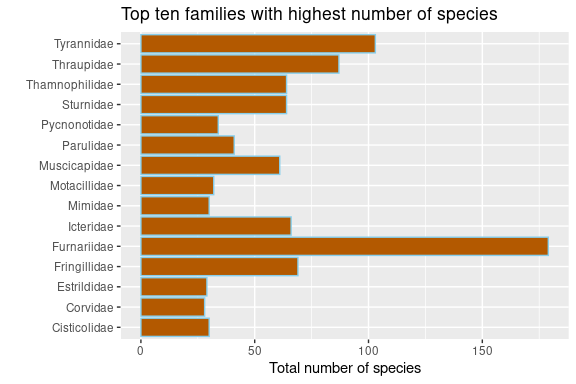

```r
passerines %>% group_by(Family) %>% tidyr::drop_na(Family) %>%
  summarize(n=n_distinct(scientificNameStd)) %>%
  arrange(desc(n)) %>% head(15) %>% collect() %>% ggplot(aes(x=Family, y=n)) +
  geom_bar(stat='identity',color='skyblue',fill='#b35900') + xlab("") +
  ggtitle('Top ten families with highest number of species') + coord_flip() + ylab('Total number of species')
```

```r
#Get passerines data
data(passerines)

#Get mean wing length and sample size per species and sex
passerines %>% group_by(scientificNameStd, Sex) %>% filter(Sex %in% c(1,2)) %>%
  summarise(wing_length = mean(Wing),
            sample_size = n()) %>% head(5)
```

```
#> # A tibble: 5 × 4
#> # Groups:   scientificNameStd [3]
#>   scientificNameStd         Sex   wing_length sample_size
#>   <chr>                     <fct>       <dbl>       <int>
#> 1 Abroscopus albogularis    2            53.5           1
#> 2 Acridotheres cristatellus 1           138             1
#> 3 Acridotheres cristatellus 2           134             1
#> 4 Acridotheres fuscus       1           122             1
#> 5 Acridotheres fuscus       2           129             1
```

Now we want to plot a boxplot of wing length

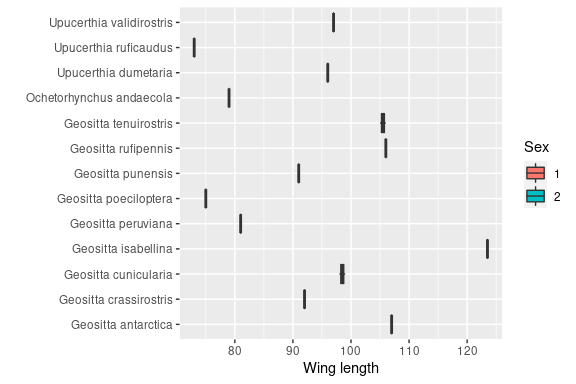

```r
passerines %>% group_by(scientificNameStd, Sex) %>% filter(Sex %in% c(1,2)) %>%
  head(15) %>% collect() %>% ggplot(aes(x=as.factor(`scientificNameStd`), y=Wing, fill=Sex)) + geom_boxplot() + coord_flip() +
  xlab("") + ylab("Wing length")
```

## Joins

Let’s join passerines and migbehav_birds by scientificNameStd, only retaining species for which both datasets have entries.

```r
migbehav_passerines <- inner_join(passerines, migbehav_birds, by="scientificNameStd", copy = TRUE)
```

**Note:** You need to be careful when merging datasets, as some datasets have unique values for one species, while other datasets have multiple records for one species. I also haven’t cross-checked if data entries occur multiple times in different datasets. Please also have a look at the glossary before merging multiple datasets, as some datasets contain variables with the same names.

```r
migbehav_passerines %>% arrange(desc(`Bill L`)) %>% select(scientificNameStd, `Bill L`, Migratory_status) %>% unique() %>% head(10)
```

```
#>                  scientificNameStd Bill L     Migratory_status
#> 1  Campylorhamphus trochilirostris 94.150             resident
#> 2                 Epimachus meyeri 87.000             resident
#> 3                     Corvus corax 79.590 dispersive migratory
#> 4              Drymornis bridgesii 79.530             resident
#> 5            Psarocolius montezuma 74.410             resident
#> 6         Heteralocha acutirostris 73.825             resident
#> 7              Nasica longirostris 73.680             resident
#> 8      Campylorhamphus falcularius 70.735             resident
#> 9              Psarocolius wagleri 70.500             resident
#> 10             Nasica longirostris 70.330             resident
```

Alternatively, we might want to join datasets, which contain the same variables. For example, we want to get the Body mass of all species from elton_birds and elton_mammals.

```r
data(elton_birds); data(elton_mammals)
eltontraits <- full_join(elton_mammals, elton_birds)
eltontraits %>% select(scientificNameStd, BodyMass.Value) %>%
  arrange(desc(BodyMass.Value)) %>% head(10)
```

```
#>           scientificNameStd BodyMass.Value
#> 1     Balaenoptera musculus      190000000
#> 2        Balaena mysticetus      100000000
#> 3     Balaenoptera physalus       70000000
#> 4  Balaenoptera bonaerensis       35089916
#> 5         Caperea marginata       32000000
#> 6    Megaptera novaeangliae       30000000
#> 7     Eschrichtius robustus       28500000
#> 8       Eubalaena australis       23000000
#> 9       Eubalaena glacialis       23000000
#> 10       Eubalaena japonica       23000000
```

Now, you should be able to work with subsets or aggregates of the data that you are interested in.